# BTS through Spotify Data

Author

Alana Peters

# BTS As an Artist

Author: Alana Peters

## This is BTS

[figure not shown]

BTS, also known as Bangtan Sonyeondan, is a South Korean group that debuted in 2013. They have 7 members, 3 rappers (RM, SUGA/Agust D and J-hope) and 4 vocalists (Jin, Jimin, V and Junkook). Although orginally a hip-hop group, their music has expanded into various styles and a wide range of genres. Their albums are based on different works of literature, philosophy and psychology and their lyrics touch on topics such as mental health, the troubles of youth, coming of age, loss, the journey of self-love, problems with a corrupt and individualistic society and the consequences of fame. They are also known for their powerful performances using different dance styles.

## BTS Discography

BTS have released 9 full studio albums and 6 shorter EP’s. They have also released 2 singles. Their discography includes Korean albums, Japanese albums, English singles and solo works, including 10 solo albums and 5 mixtapes across all members.

## My Favorites

My favorite music video is “black swan”. The song is about the fear of losing passion for making art and is inspired by orchestral music. It therefore also incorporates contemporary dance in its choreography.

**Black Swan Music Video**

[video not shown]

My favorite performance is that of “Dionysus” at a Asian award show. The song is very high energy and so is the performance. It also includes a dance breaks!

**Dionysus Performance**

[video not shown]

My favorite lyrics are those of “Spring Day**“**, a song about loss and grief. The lyrics have been translated from Korean into English.

**Spring Day Lyrics**

> Honestly, I miss you.  
> But now I’ll erase you  
> Because that will hurt less  
> than resenting you.

# BTS Through Their Spotify Data

## The Data Source

The data used is from a downloaded 2022 Spotify API dataset. In the data preparation section I added whether each song by BTS had a choreography or not, which I did based on looking at whether each song has a pre-planned dance routine.

## Importing the Data

```r
# This is the data that file that I imported
Spotify <- read.csv(file = "Spotify_data_2022.csv", header = TRUE, row.names=NULL)

# These are the packages I downloaded
library(ggplot2)
library(dplyr)
library(knitr)
library(stringr)
```

## Data Preparation

```r
# Firstly, I made a dataframe that only included tracks with BTS as the main artist
BTSdatafull <- subset(Spotify, artists %in% c("BTS", "BTS;Halsey", "BTS;Juice WRLD", "BTS;Charli XCX"))

# Secondly, I removed all duplicates tracks from the dataframe
BTSdata <- BTSdatafull |> distinct(track_name, .keep_all = TRUE)

# Thirdly, I added in an extra column that described whether the song had a cheoreography or not
BTSdata$choreography <- c("yes", "no", "yes", "yes", "yes", "yes", "no", "yes", "yes", "yes", "no", "yes", "yes", "yes", "yes", "no", "yes", "yes", "yes", "no", "no", "no", "yes", "no", "no", "yes", "yes", "yes", "yes", "yes", "no", "yes", "no", "no", "yes", "no", "no", "no", "no", "yes", "yes", "yes", "yes", "no", "yes", "yes", "no", "yes", "yes", "no", "no", "yes", "no", "yes", "no", "yes", "yes", "no", "no", "yes", "yes", "no", "no", "no", "no", "yes", "no", "yes", "no", "no", "no", "yes", "no", "no", "yes", "yes", "yes", "no", "no", "no", "yes", "yes", "yes", "no", "no", "no", "yes", "no", "yes", "yes", "no", "no", "yes", "no", "no", "yes", "no", "no", "yes", "yes", "yes", "yes", "yes", "no", "no", "yes", "yes", "no", "no", "yes", "no", "yes", "yes")

# Fourthly, I created a subset that only incluldes the songs on a korean album and thus not singles or japanese songs
BTSdatafiltered <- subset(BTSdata, album_name %in% c("BE", "Proof", "MAP OF THE SOUL : PERSONA", "Love Yourself 轉 'Tear'", "Love Yourself 結 'Answer'", "Wings", "You Never Walk Alone", "MAP OF THE SOUL : 7", "The Most Beautiful Moment in Life Pt.1", "The Most Beautiful Moment in Life: Young Forever", "The Most Beautiful Moment in Life Pt.2", "Skool Luv Affair", "2 Cool 4 Skool", "Dark & Wild", "O!RUL8,2?", "
Love Yourself 承 'Her'"))

# Fiftly, I created a dataset that makes it easier to look at the differences between albums by grouping albums of the same series together

BTSdataalbums <- BTSdatafiltered
BTSdataalbums$album_name <- str_replace(BTSdataalbums$album_name, "MAP OF THE SOUL : PERSONA", "Map of the Soul")
BTSdataalbums$album_name <- str_replace(BTSdataalbums$album_name, "MAP OF THE SOUL : 7", "Map of the Soul")
BTSdataalbums$album_name <- str_replace(BTSdataalbums$album_name, "Love Yourself 結 'Answer'", "Love Yourself")
BTSdataalbums$album_name <- str_replace(BTSdataalbums$album_name, "Love Yourself 轉 'Tear'", "Love Yourself")
BTSdataalbums$album_name <- str_replace(BTSdataalbums$album_name, "Love Yourself 承 'Her'", "Love Yourself")
BTSdataalbums$album_name <- str_replace(BTSdataalbums$album_name, "You Never Walk Alone", "Wings")
BTSdataalbums$album_name <- str_replace(BTSdataalbums$album_name, "The Most Beautiful Moment in Life Pt.2", "The Most Beautiful Moment in Life")
BTSdataalbums$album_name <- str_replace(BTSdataalbums$album_name, "The Most Beautiful Moment in Life Pt.1", "The Most Beautiful Moment in Life")
BTSdataalbums$album_name <- str_replace(BTSdataalbums$album_name, "The Most Beautiful Moment in Life: Young Forever", "The Most Beautiful Moment in Life")
BTSdataalbums$album_name <- str_replace(BTSdataalbums$album_name, "2 Cool 4 Skool", "Skool Trilogy")
BTSdataalbums$album_name <- str_replace(BTSdataalbums$album_name, "Skool Luv Affair", "Skool Trilogy")
```

## What the Data Looks Like

Following is a sample of what the dataframe looks like

```r
BTSdatafiltered |> dplyr::slice_sample(n=5) |> knitr::kable(digits = 2)
```

| artists | album_name | track_name | popularity | duration_ms | explicit | danceability | energy | key | loudness | mode | speechiness | acousticness | instrumentalness | liveness | valence | tempo | time_signature | track_genre | choreography |
| --- | --- | --- | --- | --- | --- | --- | --- | --- | --- | --- | --- | --- | --- | --- | --- | --- | --- | --- | --- |
| BTS | Proof | Yet To Come | 85 | 193593 | FALSE | 0.56 | 0.88 | 1 | -4.52 | 1 | 0.19 | 0.04 | 0 | 0.33 | 0.68 | 172.03 | 4 | k-pop | no |
| BTS | Wings | Stigma | 67 | 216063 | FALSE | 0.57 | 0.48 | 0 | -5.56 | 0 | 0.09 | 0.15 | 0 | 0.14 | 0.34 | 136.44 | 4 | k-pop | yes |
| BTS | Love Yourself 轉 ‘Tear’ | FAKE LOVE | 76 | 242333 | FALSE | 0.56 | 0.72 | 2 | -4.52 | 0 | 0.04 | 0.00 | 0 | 0.31 | 0.34 | 77.50 | 4 | k-pop | yes |
| BTS | The Most Beautiful Moment in Life Pt.2 | Butterfly | 70 | 238861 | FALSE | 0.46 | 0.78 | 6 | -4.50 | 1 | 0.06 | 0.01 | 0 | 0.12 | 0.29 | 149.99 | 4 | k-pop | yes |
| BTS | The Most Beautiful Moment in Life Pt.1 | I Need U | 71 | 210986 | FALSE | 0.48 | 0.88 | 5 | -3.10 | 0 | 0.07 | 0.02 | 0 | 0.24 | 0.71 | 158.36 | 4 | k-pop | yes |

## Danceability and Valence

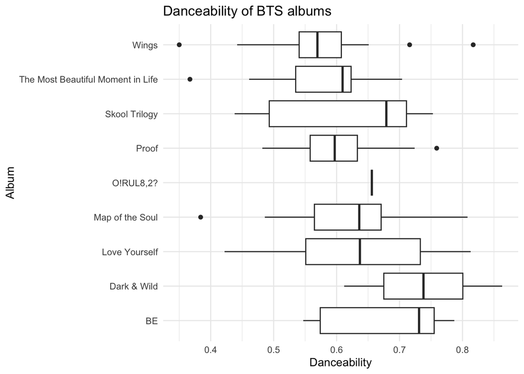

```r
ggplot(BTSdataalbums, aes(x = album_name, y = danceability)) +
  geom_boxplot() +
  labs(title = "Danceability of BTS albums", x = "Album", y = "Danceability") +
  coord_flip() +
  theme_minimal()
```

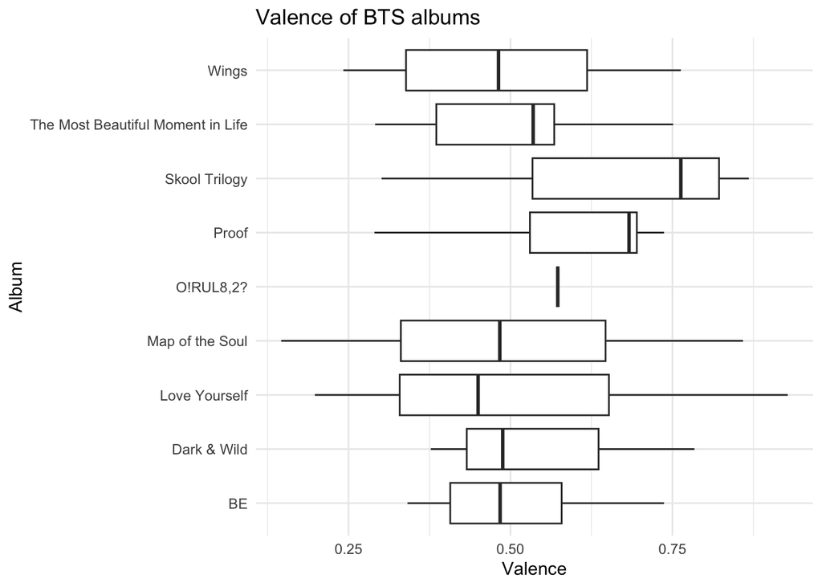

```r
ggplot(BTSdataalbums, aes(x = album_name, y = valence)) +
  geom_boxplot() +
  labs(title = "Valence of BTS albums", x = "Album", y = "Valence") +
  coord_flip() +
  theme_minimal()
```

## Are Positive Songs More Danceable?

To figure out this question we can look at the correlation between danceability and valence.

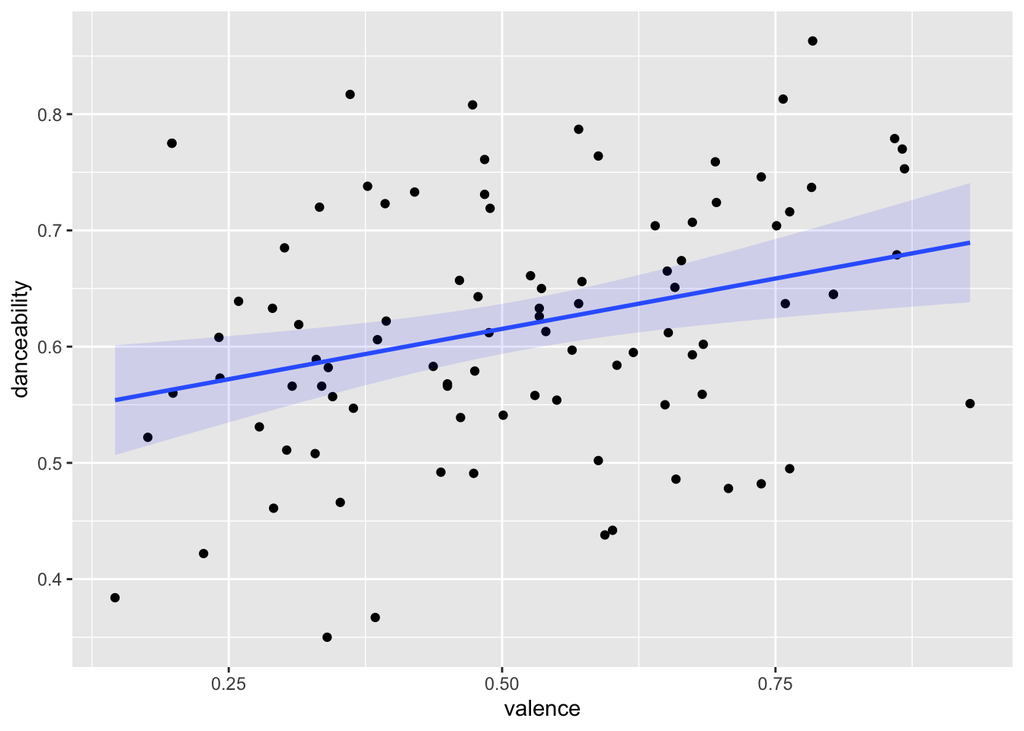

```r
ggplot(BTSdatafiltered, aes(x = valence, y = danceability) )+
  geom_point()+
  geom_smooth(method= "lm", alpha = 0.1, fill="Blue")
```

As you can see there seems to be a positive correlation between the valence of songs and their danceability!

However does this also translate to BTS cheorography?

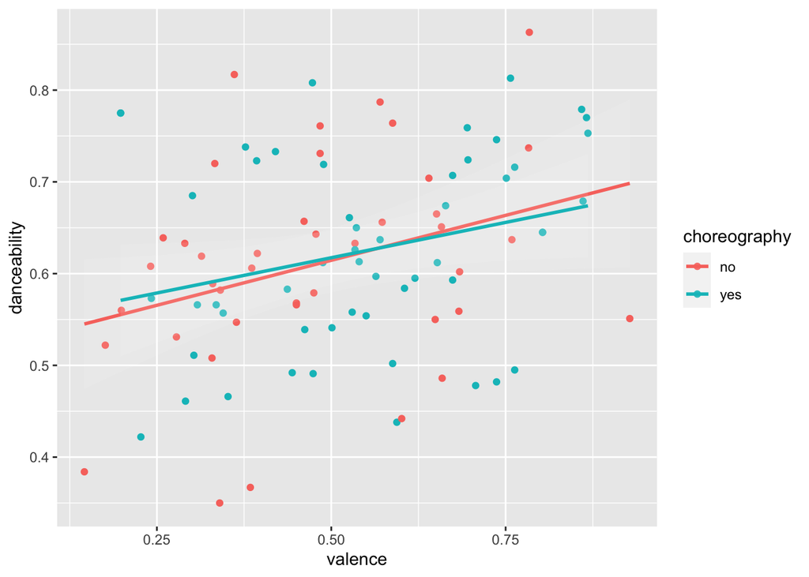

```r
ggplot(BTSdatafiltered, aes(x = valence, y = danceability, colour = choreography))+
  geom_point()+
  geom_smooth(method= "lm", alpha = 0.1, fill="white")
```

It seems that the correlation between valence and danceability for songs with and without choreography is similair. We can also note that there are songs with and without choreography for both positive and negative songs and for danceable and non-danceable songs. It seems that for BTS, the danceability or valence of a song does not matter in their decision on wether to put out a dance performance!

## Does Choreography Increase the Popularity of a Song?

Since BTS does a lot of choreographed performances it would seem that when there is a choreography the popularity of the song would increase. we can look at this through the following graphs.

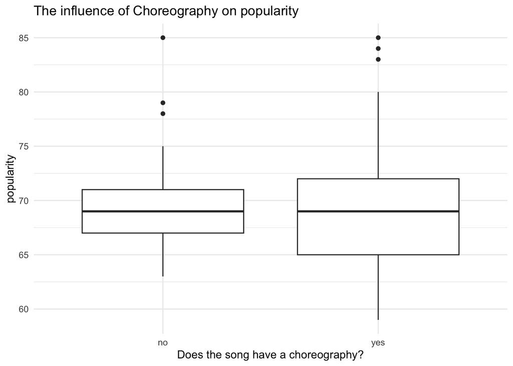

```r
ggplot(BTSdatafiltered, aes(x = choreography, y = popularity)) +
  geom_boxplot() +
  labs(title = "The influence of Choreography on popularity", x = "Does the song have a choreography?", y = "popularity") +
  theme_minimal()
```

It seems that BTS has popular songs with and without choreography and that, although the range of popularity is larger for songs with a choreography, it generally does not have an impact on the popularity of the song.

However when looking at the following performance, do you think the choreography makes it more interesting?

**O.N. Performed at Grand Central Station**

[video not shown]